# ds2 Homework 4

Chirag Shah

2019-04-20

```r
library(lasso2)
library(ISLR)
library(caret)
library(rpart)
library(rpart.plot)
library(party)
library(partykit)
library(randomForest)
library(ranger)
library(gbm)
library(plotmo)
library(pdp)
library(lime)
```

Part 1a

```r
seed = 1
data("Prostate")
ctrl <- trainControl(method = "cv")
```

Fitting a regression tree with lpsa as the response and the other variables as predictors.

Is this the same as the tree size obtained using the 1 SE rule?

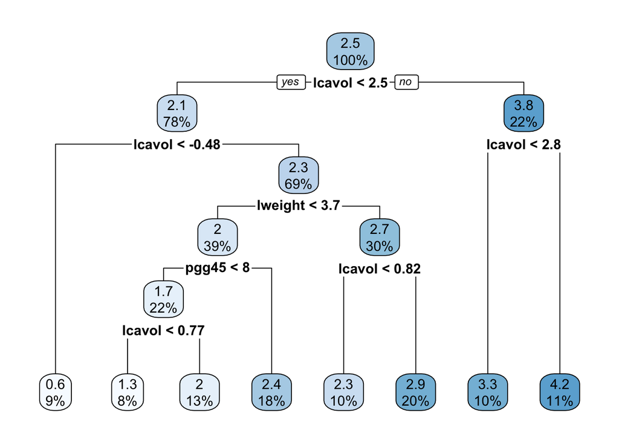

```r
set.seed(seed)

lpsatree <- rpart(formula = lpsa ~., data = Prostate,
                   control = rpart.control(cp = 0.001))
rpart.plot(lpsatree)
```

```r
cpTable <- printcp(lpsatree)
```

```
##
## Regression tree:
## rpart(formula = lpsa ~ ., data = Prostate, control = rpart.control(cp = 0.001))
##
## Variables actually used in tree construction:
## [1] lcavol  lweight pgg45
##
## Root node error: 127.92/97 = 1.3187
##
## n= 97
##
##         CP nsplit rel error  xerror     xstd
## 1 0.347108      0   1.00000 1.01687 0.163742
## 2 0.184647      1   0.65289 0.89137 0.112926
## 3 0.059316      2   0.46824 0.81363 0.111838
## 4 0.034756      3   0.40893 0.70667 0.092263
## 5 0.034609      4   0.37417 0.70171 0.090879
## 6 0.021564      5   0.33956 0.69128 0.090257
## 7 0.021470      6   0.31800 0.67139 0.080849
## 8 0.001000      7   0.29653 0.64305 0.081145
```

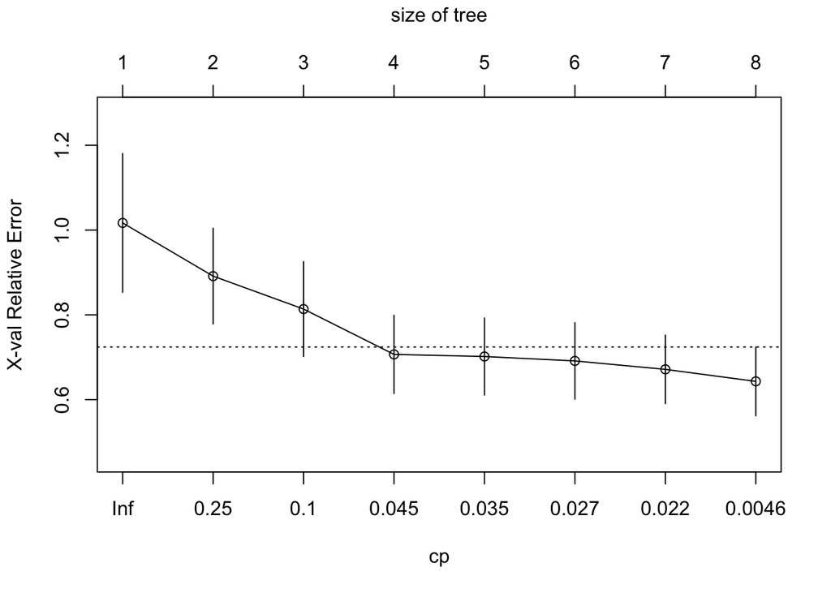

```r
plotcp(lpsatree)
```

```r
minErr <- which.min(cpTable[,4])
```

Using cross-validation, the optimal tree size is 8.

```r
#using the 1 SE rule

cpTable[cpTable[,4] < cpTable[minErr,4] + cpTable[minErr,5], 2][1] + 1
```

```
## 4
## 4
```

The tree size obtained using the 1 SE rule is 4 which is different than cross validation.

Part 1b

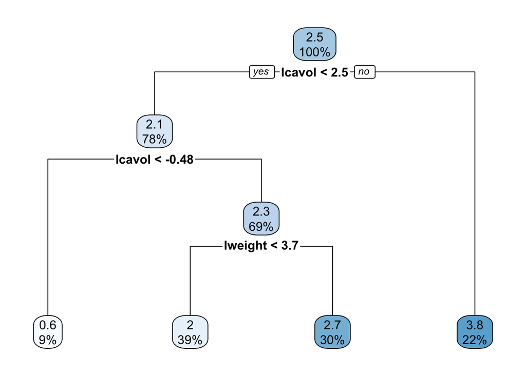

```r
treeb <- prune(lpsatree, cp = cpTable[cpTable[,4] < cpTable[minErr,4] + cpTable[minErr,5], 1][1])
rpart.plot(treeb)
```

I am selecting the terminal noed for when lcavol is not less than 2.5. The mean lpsa for observations greater than 2.5 is 3.8. 22% of the observations are in this terminal node.

Part 1c

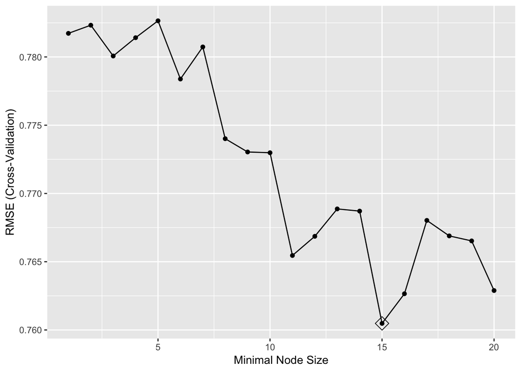

```r
bagging.grid <- expand.grid(mtry = 8,
                       splitrule = "variance",
                       min.node.size = 1:20)

set.seed(1)

bagging <- train(lpsa~., Prostate,
                method = "ranger",
                tuneGrid = bagging.grid,
                trControl = ctrl,
                importance = 'permutation')

ggplot(bagging, highlight = TRUE)
```

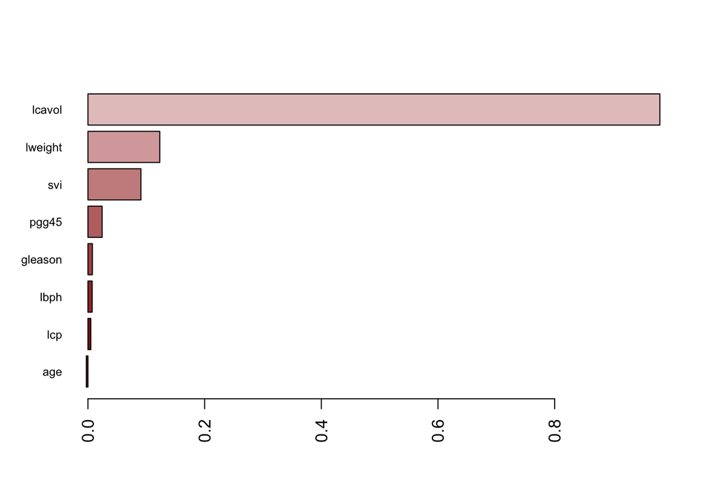

```r
barplot(sort(ranger::importance(bagging$finalModel), decreasing = FALSE),
        las = 2, horiz = TRUE, cex.names = 0.7,
        col = colorRampPalette(colors = c("darkred","white","darkblue"))(19))
```

```r
bagging$results[which.min(bagging$results[,5]),]
```

```
##   mtry splitrule min.node.size      RMSE  Rsquared       MAE    RMSESD
## 6    8  variance             6 0.7783825 0.5876399 0.6406368 0.1444136
##   RsquaredSD     MAESD
## 6   0.149867 0.1342854
```

The variable importance from highest to lowest is lcavol, lweight, svi, pgg45, gleason, lbph, lcp, and age.

Part 1d

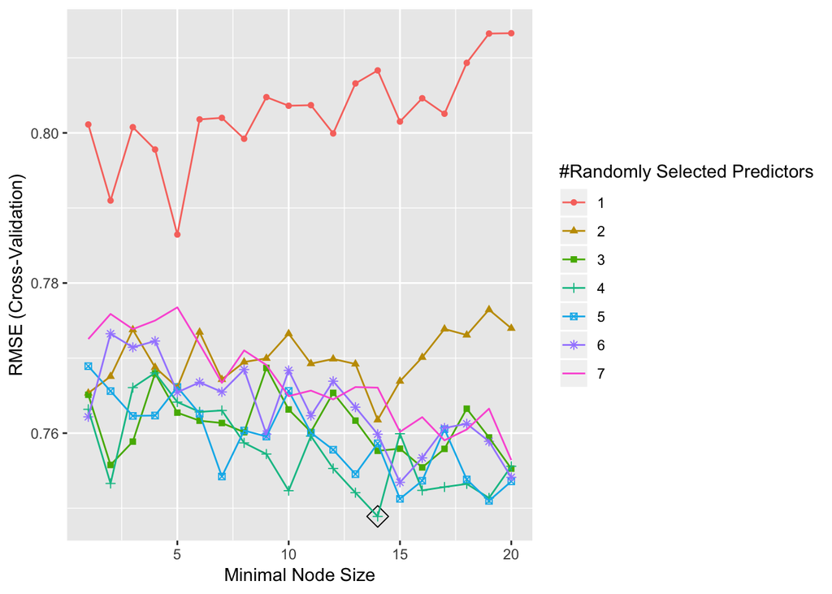

```r
rf.grid <- expand.grid(mtry = 1:7,
                       splitrule = "variance",
                       min.node.size = 1:20)

set.seed(1)

rf.fit <- train(lpsa~., Prostate,
                method = "ranger",
                tuneGrid = rf.grid,
                trControl = ctrl,
                importance = 'permutation')

ggplot(rf.fit, highlight = TRUE)
```

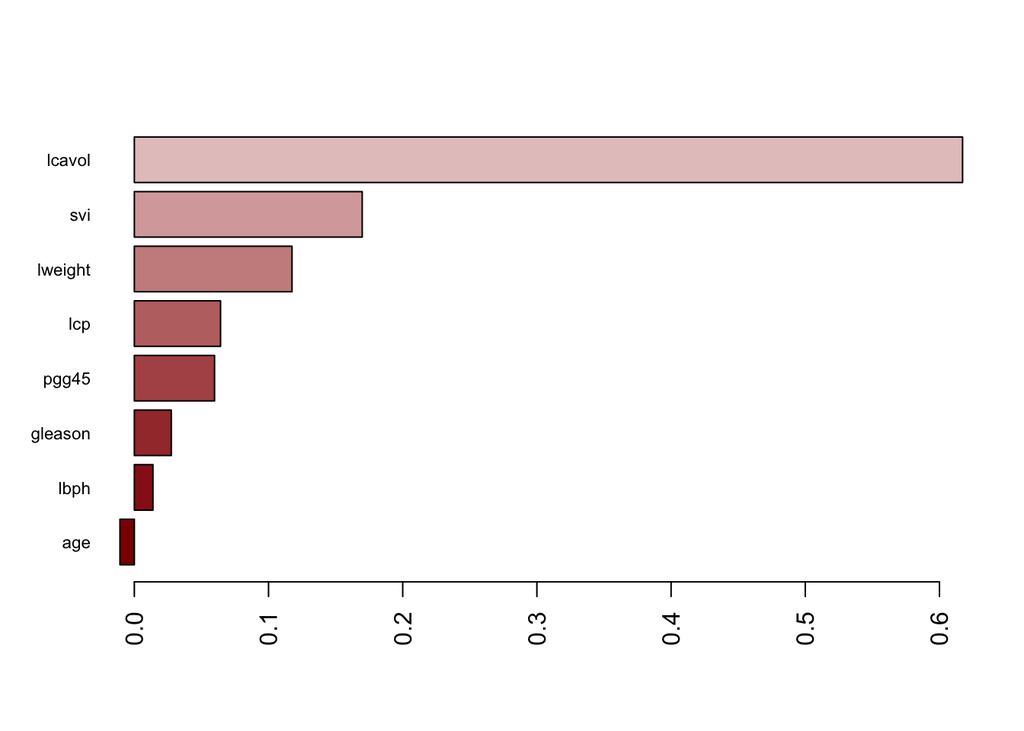

```r
barplot(sort(ranger::importance(rf.fit$finalModel), decreasing = FALSE),
        las = 2, horiz = TRUE, cex.names = 0.7,
        col = colorRampPalette(colors = c("darkred","white","darkblue"))(19))
```

```r
rf.fit$results[which.min(rf.fit$results[,5]),]
```

```
##     mtry splitrule min.node.size      RMSE  Rsquared       MAE    RMSESD
## 125    7  variance             5 0.7767589 0.5952353 0.6345633 0.1443511
##     RsquaredSD     MAESD
## 125  0.1483151 0.1362274
```

The variable importance from highest to lowest is lcavol, svi, lweight, lcp, pgg45, gleason, lbph, and age.

Part 1e

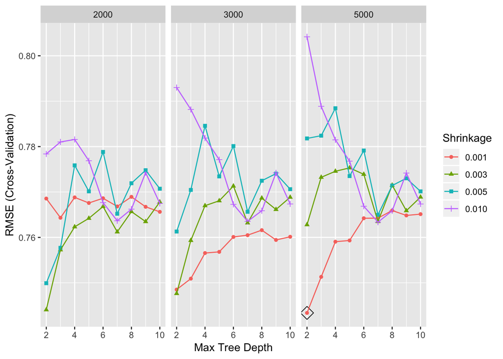

```r
gbm.grid <- expand.grid(n.trees = c(2000,3000,5000),
                        interaction.depth = 2:10,
                        shrinkage = c(0.01, 0.001,0.003,0.005),
                        n.minobsinnode = 1)

set.seed(1)

gbm.fit <- train(lpsa ~., Prostate,
                 method = "gbm",
                 tuneGrid = gbm.grid,
                 verbose = FALSE,
                 trControl = ctrl)

ggplot(gbm.fit, highlight = TRUE)
```

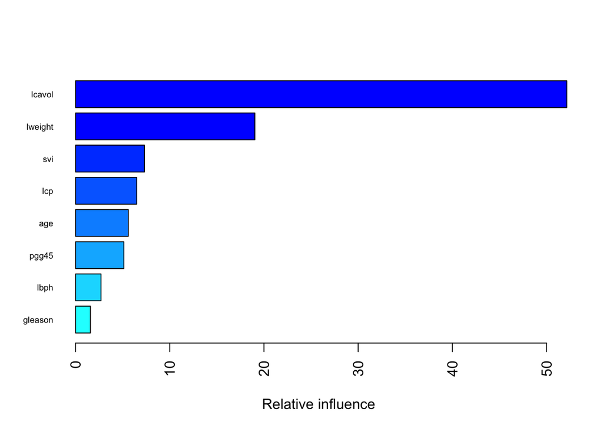

```
##             var   rel.inf
## lcavol   lcavol 52.147135
## lweight lweight 19.035587
## svi         svi  7.316331
## lcp         lcp  6.491809
## age         age  5.597326
## pgg45     pgg45  5.130606
## lbph       lbph  2.703727
## gleason gleason  1.577479
```

```r
summary(gbm.fit$finalModel, las = 2, cBars = 19, cex.names = 0.6)
```

The variable importance from highest to lowest is lcavol, lweight, svi, lcp, age, pgg45, lbph, and gleason.

Part 1f

```r
resamp = resamples(list(rf = rf.fit, gbm = gbm.fit, bagging = bagging))
summary(resamp)
```

```
##
## Call:
## summary.resamples(object = resamp)
##
## Models: rf, gbm, bagging
## Number of resamples: 10
##
## MAE
##              Min.   1st Qu.    Median      Mean   3rd Qu.      Max. NA's
## rf      0.4388518 0.5752939 0.5988010 0.6240935 0.6357321 0.9806087    0
## gbm     0.4191029 0.5282535 0.5641767 0.6076525 0.6528855 0.8839551    0
## bagging 0.4744007 0.5785223 0.5947370 0.6325892 0.6277988 0.9632561    0
##
## RMSE
##              Min.   1st Qu.    Median      Mean   3rd Qu.      Max. NA's
## rf      0.4936100 0.6643460 0.7544224 0.7489068 0.8336855 1.0827494    0
## gbm     0.5159758 0.6401619 0.7454831 0.7433731 0.8013531 0.9630145    0
## bagging 0.5560895 0.6843114 0.7420510 0.7604800 0.8229470 1.0751279    0
##
## Rsquared
##              Min.   1st Qu.    Median      Mean   3rd Qu.      Max. NA's
## rf      0.2612565 0.6004245 0.6769932 0.6350320 0.7105999 0.7609664    0
## gbm     0.3849614 0.5831853 0.6522304 0.6357958 0.7192895 0.7868307    0
## bagging 0.2115985 0.5719590 0.6745214 0.6139633 0.7080146 0.7496108    0
```

Based on the RMSE, I will select the GBM model as it has the lowest RMSE.

Part 2a

```r
data("OJ")

set.seed(1)

rowTrain = createDataPartition(y = OJ$Purchase,
                                p = 0.747,
                                list = FALSE)

ctrl <- trainControl(method = "repeatedcv")
```

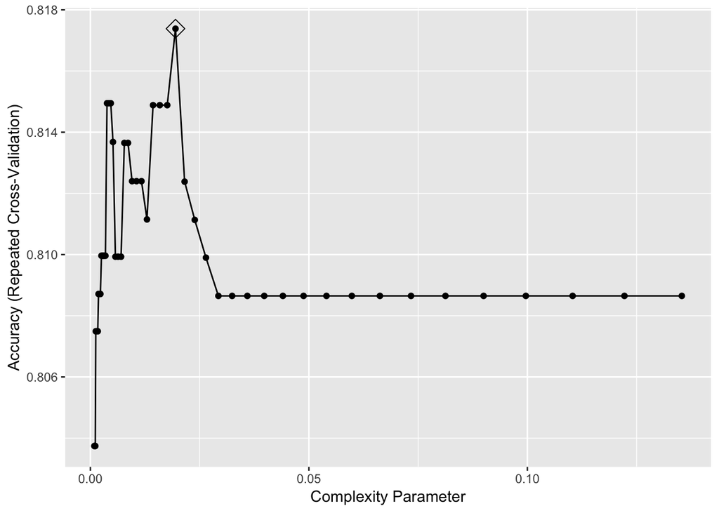

```r
set.seed(1)

rpart.class <- train(Purchase ~., OJ,
                   subset = rowTrain,
                   method = "rpart",
                   tuneGrid = data.frame(cp = exp(seq(-7,-2, len = 50))),
                   trControl = ctrl,
                   metric = "Accuracy")

ggplot(rpart.class, highlight = T)
```

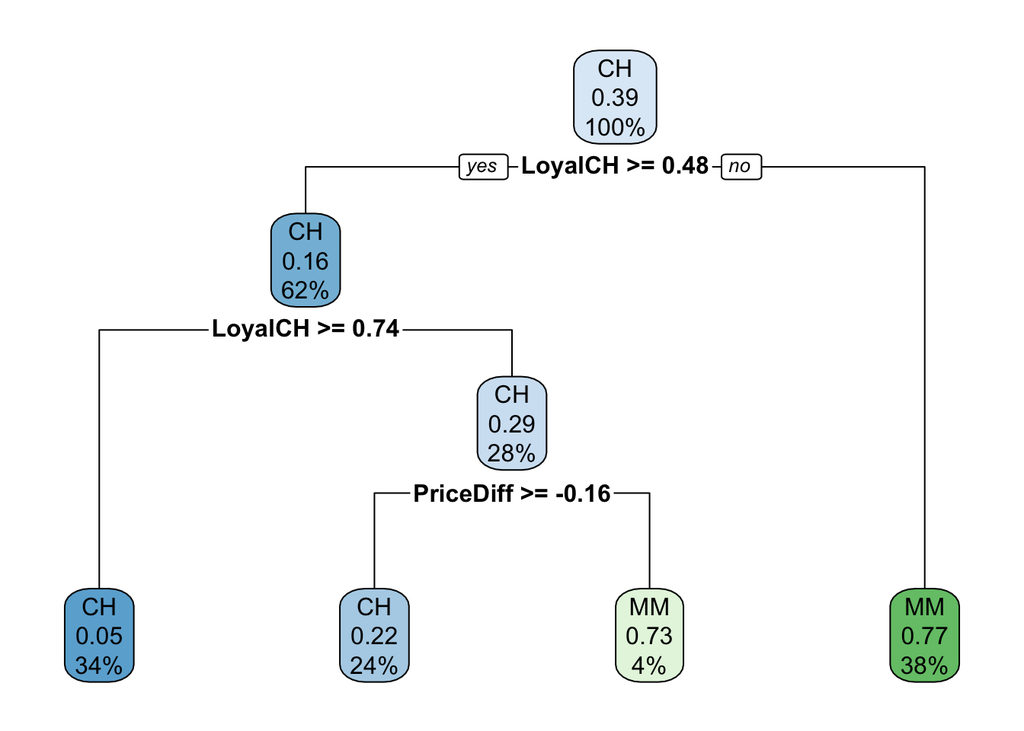

```r
rpart.plot(rpart.class$finalModel)
```

```r
rpart.pred <- predict(rpart.class, newdata = OJ[-rowTrain,])

error_rate <- mean(rpart.pred != OJ$Purchase[-rowTrain])
```

The test classification error rate is 0.185.

Part 2b

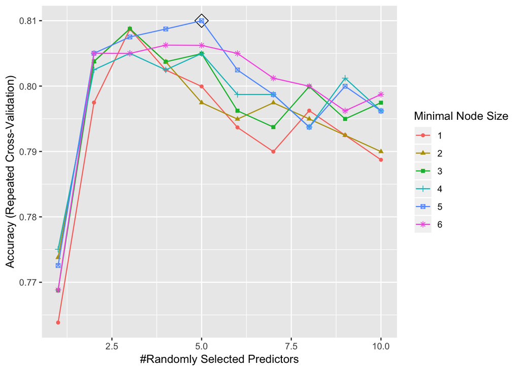

```r
rf.grid <- expand.grid(mtry = 1:10,
                       splitrule = "gini",
                       min.node.size = 1:6)

set.seed(1)

rf.class <- train(Purchase ~., OJ,
                subset = rowTrain,
                method = "ranger",
                tuneGrid = rf.grid,
                metric = "Accuracy",
                trControl = ctrl,
                importance = 'permutation')

ggplot(rf.class, highlight = TRUE)
```

```r
rf.pred = predict(rf.class, newdata = OJ[-rowTrain,])

error_rateb <- mean(rf.pred != OJ$Purchase[-rowTrain])
```

The test classification error rate is 0.189.

Part 2c

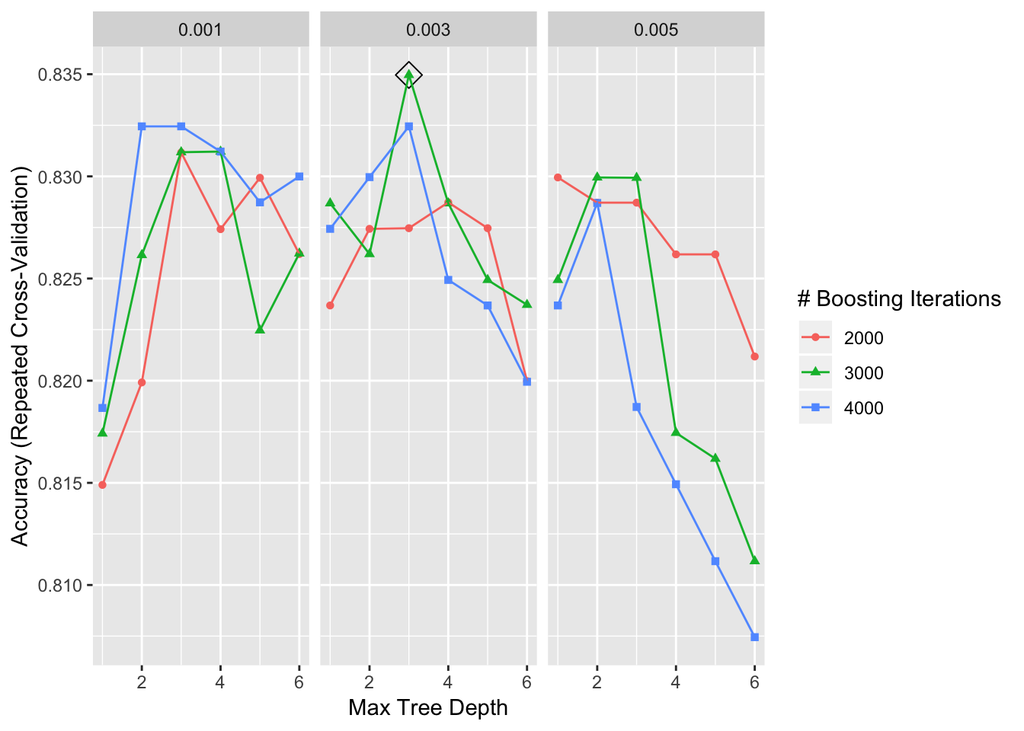

```r
boosting.grid <- expand.grid(n.trees = c(2000,3000,4000),
                        interaction.depth = 1:6,
                        shrinkage = c(0.001,0.003,0.005),
                        n.minobsinnode = 1)

set.seed(1)

boosting.fit <- train(Purchase ~., OJ,
                 subset = rowTrain,
                 tuneGrid = boosting.grid,
                 trControl = ctrl,
                 method = "gbm",
                 distribution = "adaboost",
                 metric = "Accuracy",
                 verbose = FALSE)

ggplot(boosting.fit, highlight = TRUE)
```

```r
gbm.pred = predict(boosting.fit, newdata = OJ[-rowTrain,])

error_ratec <- mean(gbm.pred != OJ$Purchase[-rowTrain])
```

The test classification error rate is 0.155.